# An Analysis of Police Brutality and its Pervasiveness in the US

Calvin Tzen, Lesley Xu, Olivia Price

11/14/2022

## Dynamic Paragraph

The data set consisting of all the murders committed by police in the United States from 2015 to 2017 is made up of 2535 observations, meaning there were 2535 recorded police killings in that time period. After performing multiple summary statistics on the police killing data set, as well as the United States poverty data set, we were able to get a general idea about what the data could tell us. The state with the highest amount of people under the poverty line was MS, whereas the state with the lowest amount of their population beneath the poverty line was NJ. This information was important to us as we could see if there was a connection between statewide poverty and police brutality. To get an overview on the demographics of those killed, we found that 1334 out of 2535 of those killed were people of color. When looking at gender, we found that 2428 out of 2535 of those killed were male.

## Description on the summary table

We grouped our data set by the feature of states. The table is included because the stakeholders can pull out the meaningful information and statistics related to police shooting of a certain state clearly and effectively. The table reveals the total number of deaths, the races of the victims, the ages of the youngest and oldest victims from each state, and the percentage of whether body camera is used. This summary table provides a brief insight of the police shooting data for stakeholders besides the data visualization charts. For example, if the stakeholder wants to have a glance on the races of police shooting victims in CA, they will notice the highest total number of deaths and the largest group of Hispanic victims.

```r
aggregated_table <- knitr::kable(
  aggregate,
  format = "markdown",
  caption = "Aggregated Table on Police Killing",
  align = "c"
  )
aggregated_table
```

Aggregated Table on Police Killing

| state | deaths | white | unknown | other | native | hispanic | black | asian | youngest | oldest | body_camera_on | body_camera_off |
| --- | --- | --- | --- | --- | --- | --- | --- | --- | --- | --- | --- | --- |
| AK | 15 | 7 | 1 | 0 | 6 | 0 | 1 | 0 | 19 | 49 | 0.07 | 0.93 |
| AL | 50 | 32 | 4 | 0 | 0 | 0 | 14 | 0 | 16 | 77 | 0.22 | 0.78 |
| AR | 26 | 16 | 4 | 0 | 0 | 0 | 6 | 0 | 16 | 83 | 0.04 | 0.96 |
| AZ | 118 | 57 | 11 | 0 | 8 | 37 | 5 | 0 | 17 | 70 | 0.13 | 0.87 |
| CA | 424 | 125 | 41 | 8 | 1 | 169 | 65 | 15 | 14 | 86 | 0.13 | 0.87 |
| CO | 74 | 32 | 10 | 0 | 1 | 21 | 8 | 2 | 17 | 72 | 0.11 | 0.89 |
| CT | 9 | 5 | 2 | 0 | 0 | 2 | 0 | 0 | 16 | 57 | 0.00 | 1.00 |
| DC | 11 | 1 | 0 | 0 | 0 | 0 | 10 | 0 | 21 | 63 | 0.27 | 0.73 |
| DE | 8 | 4 | 0 | 0 | 0 | 0 | 4 | 0 | 21 | 60 | 0.25 | 0.75 |
| FL | 154 | 72 | 12 | 2 | 0 | 18 | 49 | 1 | 15 | 82 | 0.03 | 0.97 |
| GA | 70 | 33 | 7 | 0 | 0 | 6 | 23 | 1 | 18 | 72 | 0.09 | 0.91 |
| HI | 11 | 1 | 0 | 7 | 0 | 0 | 1 | 2 | 25 | 61 | 0.00 | 1.00 |
| IA | 12 | 9 | 0 | 0 | 0 | 0 | 3 | 0 | 21 | 53 | 0.25 | 0.75 |
| ID | 17 | 12 | 1 | 0 | 0 | 4 | 0 | 0 | 26 | 62 | 0.29 | 0.71 |
| IL | 62 | 18 | 3 | 0 | 0 | 7 | 34 | 0 | 16 | 63 | 0.06 | 0.94 |
| IN | 43 | 24 | 3 | 0 | 0 | 3 | 13 | 0 | 15 | 64 | 0.14 | 0.86 |
| KS | 24 | 19 | 0 | 0 | 0 | 3 | 2 | 0 | 18 | 65 | 0.08 | 0.92 |
| KY | 43 | 34 | 1 | 0 | 0 | 2 | 6 | 0 | 18 | 67 | 0.07 | 0.93 |
| LA | 57 | 19 | 4 | 0 | 0 | 0 | 32 | 2 | 6 | 63 | 0.14 | 0.86 |
| MA | 22 | 10 | 0 | 0 | 0 | 5 | 7 | 0 | 23 | 57 | 0.00 | 1.00 |
| MD | 38 | 12 | 2 | 0 | 0 | 0 | 24 | 0 | 16 | 67 | 0.21 | 0.79 |
| ME | 13 | 11 | 0 | 1 | 0 | 0 | 1 | 0 | 18 | 65 | 0.00 | 1.00 |
| MI | 37 | 20 | 1 | 0 | 0 | 1 | 15 | 0 | 17 | 73 | 0.14 | 0.86 |
| MN | 32 | 20 | 1 | 2 | 1 | 1 | 6 | 1 | 20 | 68 | 0.09 | 0.91 |
| MO | 64 | 33 | 5 | 0 | 0 | 2 | 24 | 0 | 15 | 68 | 0.03 | 0.97 |
| MS | 23 | 13 | 1 | 0 | 0 | 1 | 8 | 0 | 23 | 57 | 0.00 | 1.00 |
| MT | 11 | 11 | 0 | 0 | 0 | 0 | 0 | 0 | 20 | 53 | 0.09 | 0.91 |
| NC | 69 | 37 | 1 | 0 | 0 | 2 | 28 | 1 | 18 | 75 | 0.14 | 0.86 |
| ND | 4 | 1 | 0 | 0 | 3 | 0 | 0 | 0 | 24 | 42 | 0.00 | 1.00 |
| NE | 15 | 12 | 0 | 0 | 0 | 0 | 3 | 0 | 22 | 66 | 0.07 | 0.93 |
| NH | 7 | 7 | 0 | 0 | 0 | 0 | 0 | 0 | 19 | 54 | 0.14 | 0.86 |
| NJ | 35 | 12 | 4 | 0 | 0 | 5 | 13 | 1 | 18 | 75 | 0.03 | 0.97 |
| NM | 51 | 15 | 8 | 0 | 1 | 27 | 0 | 0 | 19 | 59 | 0.20 | 0.80 |
| NV | 42 | 18 | 6 | 0 | 0 | 13 | 5 | 0 | 19 | 76 | 0.19 | 0.81 |
| NY | 45 | 17 | 2 | 0 | 0 | 3 | 22 | 1 | 17 | 66 | 0.00 | 1.00 |
| OH | 79 | 40 | 5 | 2 | 0 | 0 | 30 | 2 | 13 | 76 | 0.08 | 0.92 |
| OK | 78 | 47 | 9 | 0 | 1 | 4 | 16 | 1 | 18 | 83 | 0.12 | 0.88 |
| OR | 38 | 30 | 4 | 0 | 0 | 0 | 4 | 0 | 17 | 70 | 0.03 | 0.97 |
| PA | 51 | 24 | 4 | 0 | 0 | 2 | 21 | 0 | 12 | 91 | 0.00 | 1.00 |
| RI | 2 | 0 | 0 | 0 | 0 | 1 | 1 | 0 | 24 | 80 | 0.00 | 1.00 |
| SC | 44 | 26 | 2 | 0 | 0 | 2 | 14 | 0 | 19 | 69 | 0.09 | 0.91 |
| SD | 10 | 6 | 1 | 0 | 2 | 0 | 0 | 1 | 22 | 53 | 0.10 | 0.90 |
| TN | 59 | 41 | 3 | 1 | 0 | 2 | 11 | 1 | 18 | 86 | 0.14 | 0.86 |
| TX | 225 | 93 | 14 | 3 | 1 | 66 | 46 | 2 | 15 | 71 | 0.09 | 0.91 |
| UT | 23 | 18 | 1 | 1 | 0 | 3 | 0 | 0 | 18 | 53 | 0.35 | 0.65 |
| VA | 47 | 21 | 3 | 0 | 0 | 2 | 20 | 1 | 18 | 71 | 0.19 | 0.81 |
| VT | 3 | 2 | 0 | 0 | 1 | 0 | 0 | 0 | 29 | 76 | 1.00 | 0.00 |
| WA | 62 | 30 | 9 | 1 | 4 | 6 | 9 | 3 | 17 | 64 | 0.08 | 0.92 |
| WI | 43 | 29 | 0 | 0 | 0 | 2 | 11 | 1 | 18 | 69 | 0.14 | 0.86 |
| WV | 27 | 20 | 4 | 0 | 0 | 0 | 3 | 0 | 25 | 82 | 0.07 | 0.93 |
| WY | 8 | 5 | 1 | 0 | 1 | 1 | 0 | 0 | 23 | 50 | 0.00 | 1.00 |

## Police Killings in each state, compared to race and whether or not a body cam was used

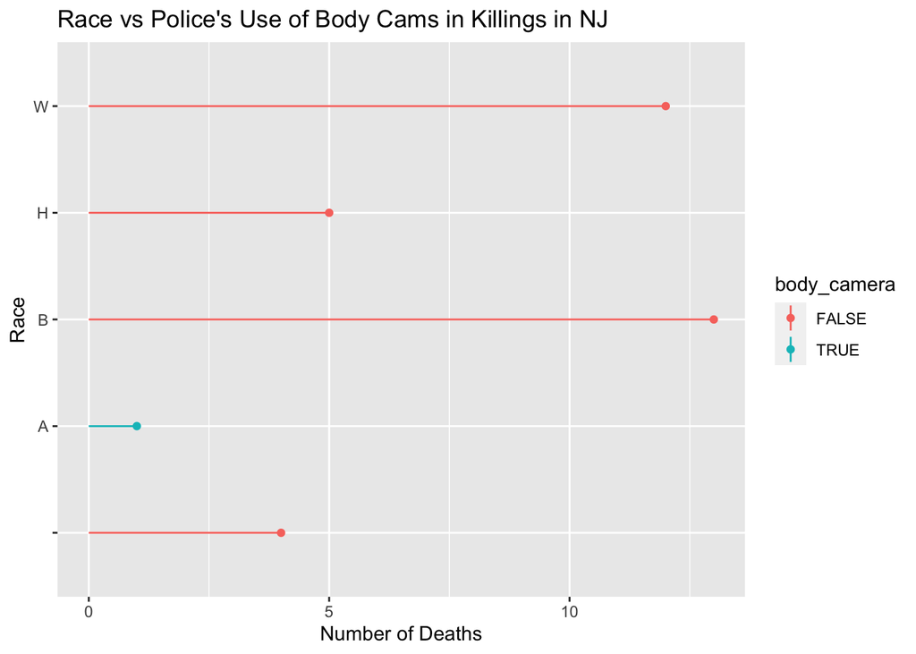

```r
body_cam_chart("NJ")
```

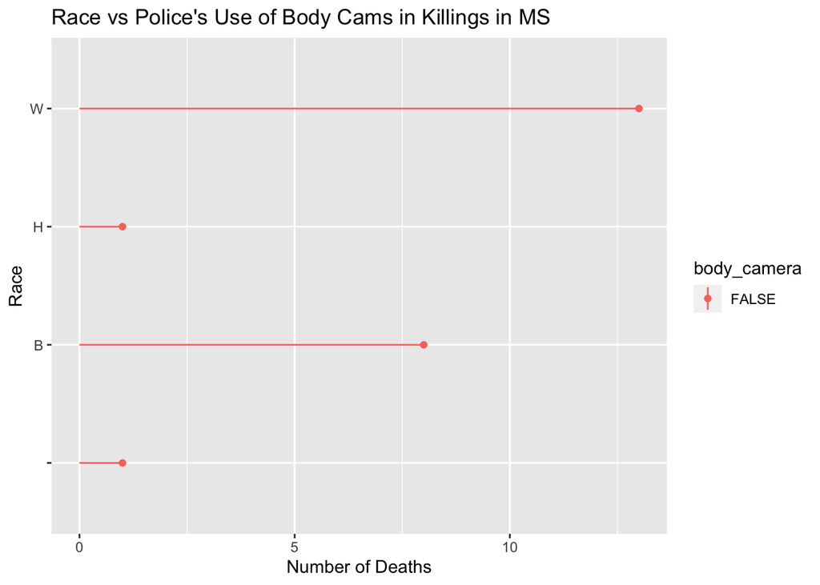

```r
body_cam_chart("MS")
```

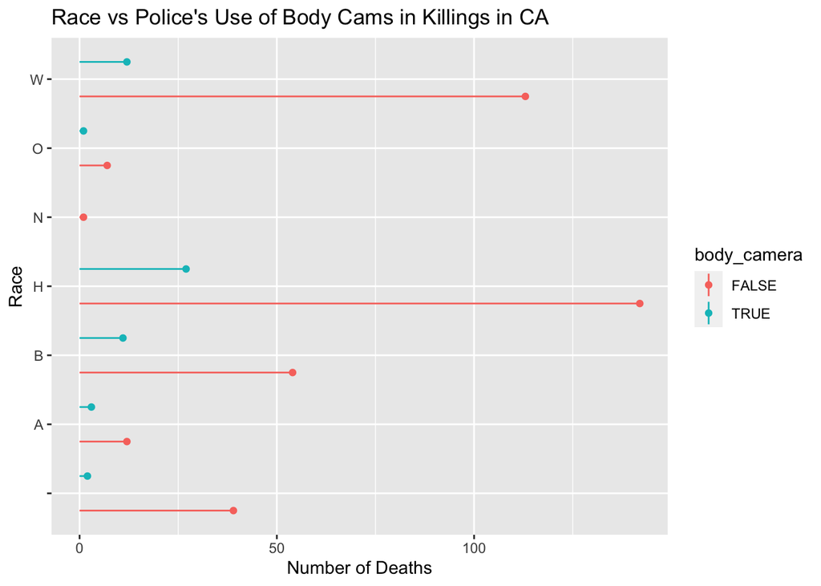

```r
body_cam_chart("CA")
```

```r
stacked_body_cam_chart("CA")
```

[output not shown]

```
## .Primitive("return")
```

## Deaths Based on Race in Different States

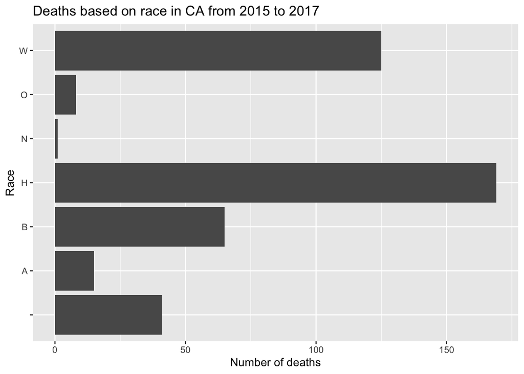

```r
# Example: a graph showing the deaths in California and another showing the deaths
# in Kentucky:
race_chart("CA")
```

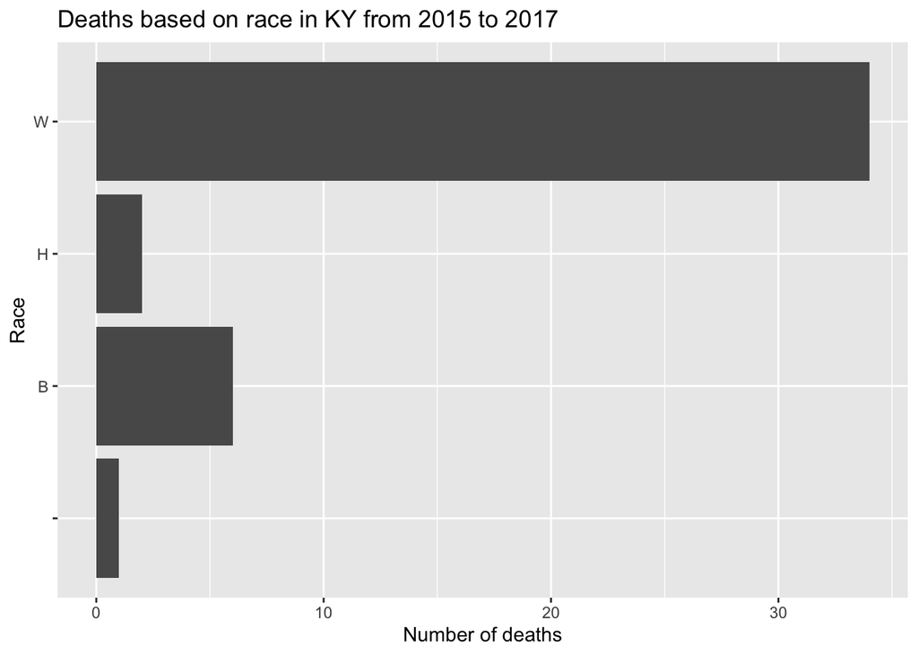

```r
race_chart("KY")
```

## Deaths based on Age in Different States

This graph displays the age distribution and frequency of victims in a given state. The age distributions in California and Kentucky are both right skewed. When looking at the minimums and maximums, California has significantly higher number of younger victims from police killing than elder victims from police killing, as well as a few high outliers; while in Kentucky, the number of younger and elder victims from police killing are much closer. Based on the age distribution of California and Kentucky, it is reasonable to infer that there are more police killing victims died at their early twenties or early thirties comparing to victims that died at a extremely old or young age.

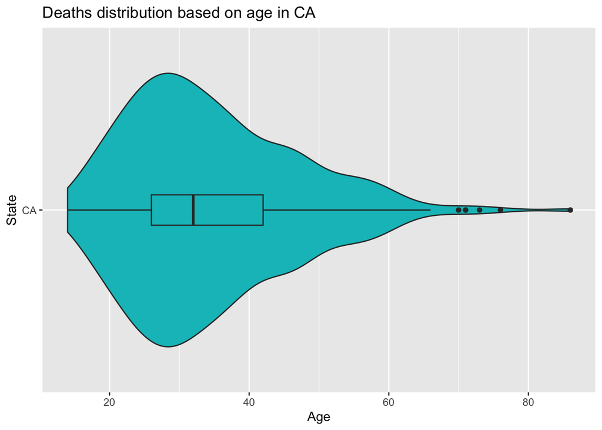

```r
# Example: a graph showing the distribution of ages deaths caused by police violence in California
# and another showing the Kentucky
plot_by_age("CA")
```

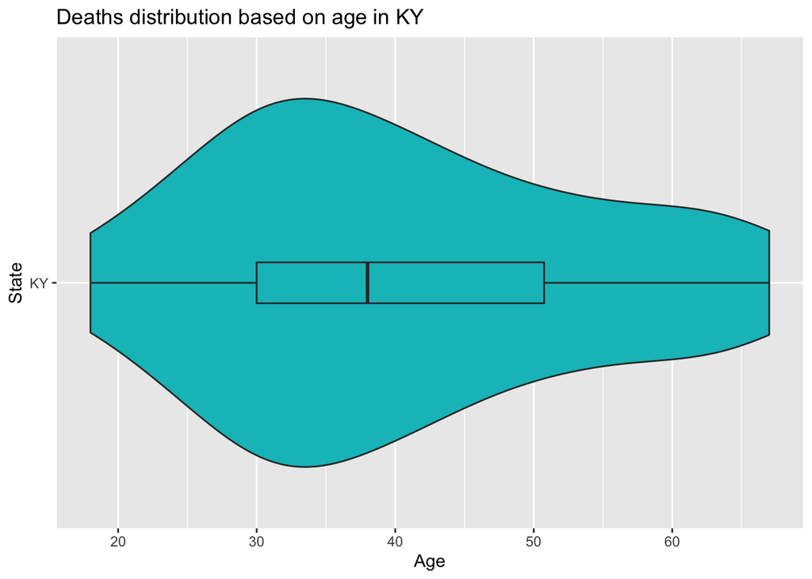

```r
plot_by_age("KY")
```